# ECON 413 Web scrapping and text analysis

Erol Taymaz  
Department of Economics  
Middle East Technical University

# Data file formats

- **csv**: Comma-separated values. Stores tabular data (numbers and text) in plain text
  - Comma-separated vs tab separated vs semi-colon separated
  - Decimal points
  - Encoding
- **Rdata**: R format
- **rds**: R format (only one object)
- **dta**: Stata format
- **sav**: SPSS format
- **xlsx**: Excel format
- **ods**: Open Document Spreadsheet

# Reading data

- File functions
  - file.exists(fileName)
  - file.info(fileName)

# Reading data

- Loading data from a file
  - read.csv
  - fread (data.table package for csv files)
  - load (for Rdata)
  - loadRDS (for rds data)
  - read.spss (foreign package)
  - read.stata (foreign package)
- Loading data from a script

```r
data <- read.table(header=TRUE, text="
    size weight cost
   small      5    6
  medium      8   10
   large     11    9
 ")
```

# Saving data

- write.csv (csv files)
- fwrite (data.table package for csv files)
- save (for Rdata)
- saveRDS (for rds data)

# html basics

# html example

[interactive chart not shown]

# css file

- css files are used for formatting

@import url(‘https://fonts.googleapis.com/css?family=Source+Sans+Pro:200,300,400,400i,600,700,900&subset=latin-ext’);

a {  
color: #cf4170;  
text-decoration: none;  
}

a:visited {color: #b12c58}

a:hover {color: #cf4170; text-decoration: underline;}

img {  
width: 100%;  
max-width: 1600px;  
}

@media screen and (max-width: 800px) {  
img {  
width: 30%;  
}  
}

.section h2 {  
margin-bottom: 20px;  
border-bottom: 1px solid #ccc;  
}

# Web scraping

- **rselenium** package
- **rvest** package
  - Read the web page by **read_html**
  - Select nodes by **html_nodes** or **html_node**
  - Extract information by **html_tables** or **html_text**
  - Extract attributes by **html_attr**

# Web scraping - Case 1

**Used car prices in Turkey**

```r
library(rvest)
library(data.table)
library(ggplot2)

url <- c("https://www.sahibinden.com/bmw/sahibinden?pagingSize=50")
fp <- read_html(url)
str(fp)
```

```
## List of 2
##  $ node:<externalptr>
##  $ doc :<externalptr>
##  - attr(*, "class")= chr [1:2] "xml_document" "xml_node"
```

```r
nilan <-  html_nodes(fp, '.result-text span')
nilan <- html_text(nilan)
nilan
```

```
## [1] "Sahibinden BMW Fiyatları & Modelleri"
## [2] "12.122 ilan"
```

```r
nilan <- nilan[2]
nilan
```

```
## [1] "12.122 ilan"
```

```r
tablo <- html_nodes(fp, "#searchResultsTable")
veri <- html_table(tablo[[1]], header = T, trim = TRUE, dec = ",", fill =TRUE)
head(veri)
```

```
##            Seri                      Model
## 1      1 Serisi 116d First Edition M Sport
## 2      4 Serisi                440i xDrive
## 3      3 Serisi               320d M Sport
## 4
## 5 <NA>     <NA>                       <NA>
## 6      5 Serisi               520i Premium
##                                                        İlan Başlığı  Yıl
## 1                 2020 MODEL SIFIR BMW 1.16D F1 KOLTUK PAZARLIK YOK 2020
## 2 2020 BMW 440i XDRIVE M SPORT - LASER LIGHT+19''JANT+HARMAN 374BG 2018
## 3  180 BİNDE HATASIZ BOYASIZ DEĞİŞENSİZ BOL EKSTRALI TRNİN EN İYİSİ 2008
## 4
## 5                                                              <NA> <NA>
## 6                                  Sahibinden Hatasız Garaj arabası 2015
##        KM  Renk        Fiyat                           İlan Tarihi
## 1      10   Gri   440.900 TL 07 Ocak\n                        2021
## 2     950   Gri 2.250.000 TL 07 Ocak\n                        2021
## 3 180.000   Gri   235.000 TL 07 Ocak\n                        2021
## 4
## 5    <NA>  <NA>         <NA>                                  <NA>
## 6 106.000 Beyaz   421.500 TL 06 Ocak\n                        2021
##         İl / İlçe
## 1 İzmirKarabağlar
## 2 İstanbulBeyoğlu
## 3   KocaeliKörfez
## 4
## 5            <NA> <NA>
## 6  SakaryaKocaali
```

- Some data cleaning …

```r
veri<-data.table(veri)
veri[, Fiyat := sub(" TL", "", Fiyat)]
veri[, Fiyat := sub("\\.", "", Fiyat)]
veri[, Fiyat := as.numeric(Fiyat)]
veri <- veri[!is.na(Fiyat)]
mean(veri$Fiyat)
```

```
## [1] 424368.4
```

- … and analysis

```r
veri<-data.table(veri)
str(veri)
```

```
## Classes 'data.table' and 'data.frame':   50 obs. of  11 variables:
##  $ V1          : chr  "" "" "" "" ...
##  $ Seri        : chr  "1 Serisi" "4 Serisi" "3 Serisi" "5 Serisi" ...
##  $ Model       : chr  "116d First Edition M Sport" "440i xDrive" "320d M Sport" "520i Premium" ...
##  $ İlan Başlığı: chr  "2020 MODEL SIFIR BMW 1.16D F1 KOLTUK PAZARLIK YOK" "2020 BMW 440i XDRIVE M SPORT - LASER LIGHT+19''JANT+HARMAN 374BG" "180 BİNDE HATASIZ BOYASIZ DEĞİŞENSİZ BOL EKSTRALI TRNİN EN İYİSİ" "Sahibinden Hatasız Garaj arabası" ...
##  $ Yıl         : chr  "2020" "2018" "2008" "2015" ...
##  $ KM          : chr  "10" "950" "180.000" "106.000" ...
##  $ Renk        : chr  "Gri" "Gri" "Gri" "Beyaz" ...
##  $ Fiyat       : num  440900 2250 235000 421500 307500 ...
##  $ İlan Tarihi : chr  "07 Ocak\n                        2021" "07 Ocak\n                        2021" "07 Ocak\n                        2021" "06 Ocak\n                        2021" ...
##  $ İl / İlçe   : chr  "İzmirKarabağlar" "İstanbulBeyoğlu" "KocaeliKörfez" "SakaryaKocaali" ...
##  $ V2          : chr  "" "" "" "" ...
##  - attr(*, ".internal.selfref")=<externalptr>
```

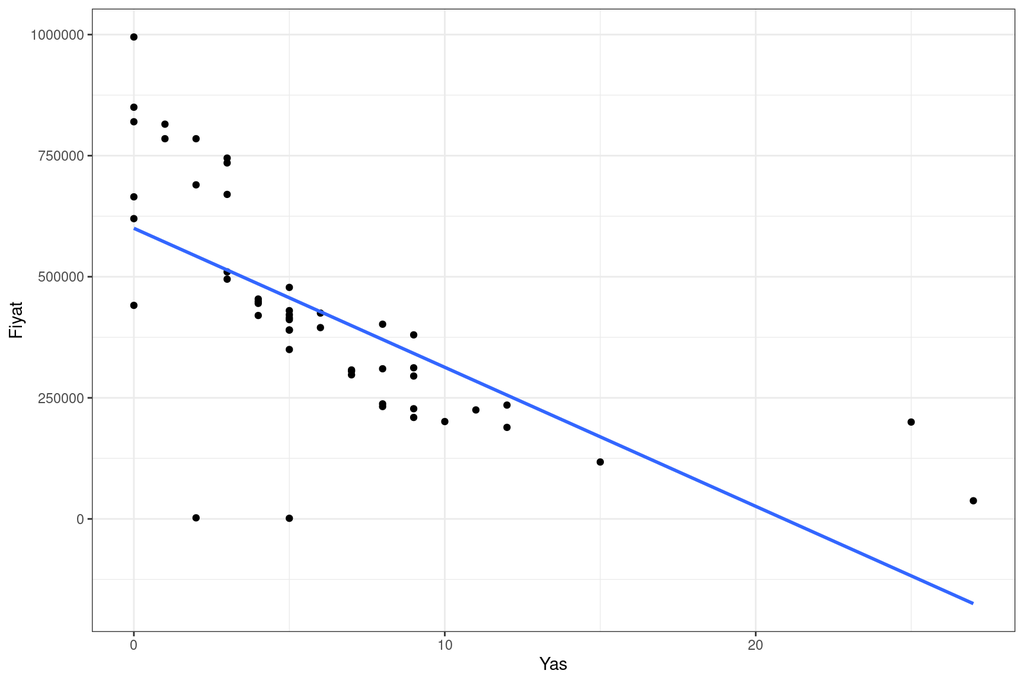

```r
veri[, Yıl := as.numeric(Yıl)]
veri[, Yas := 2020 - Yıl]

ggplot(veri) + geom_point(aes(x = Yas, y = Fiyat)) +
  geom_smooth(aes(y = Fiyat, x = Yas), method = "lm", se = FALSE) +
  theme_bw()
```

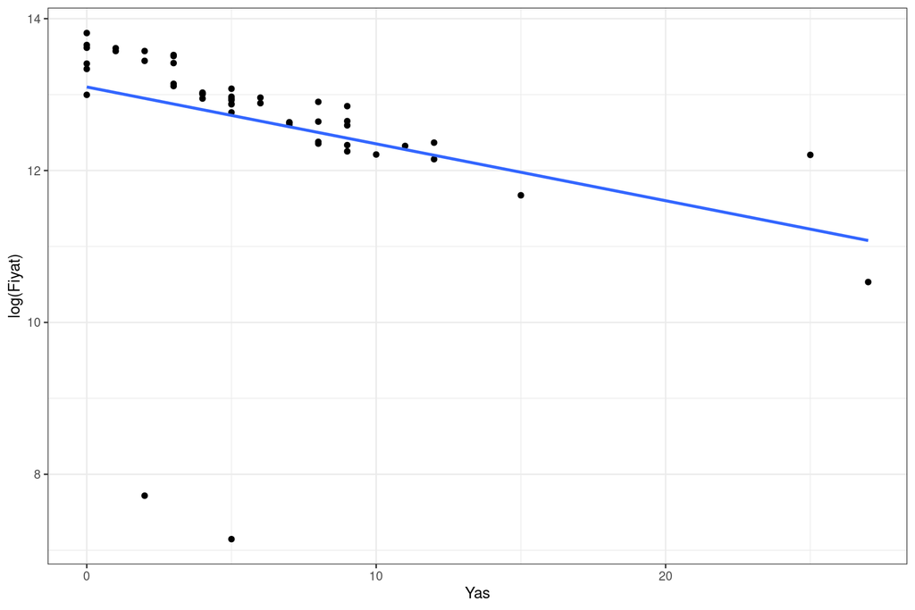

```r
ggplot(veri) + geom_point(aes(x = Yas, y = log(Fiyat))) +
  geom_smooth(aes(y = log(Fiyat), x = Yas), method = "lm", se = FALSE) +
  theme_bw()
```

```r
model_1 <- lm(log(Fiyat) ~ Yas, data = veri)
summary(model_1)
```

```
##
## Call:
## lm(formula = log(Fiyat) ~ Yas, data = veri)
##
## Residuals:
##     Min      1Q  Median      3Q     Max
## -5.5791  0.0412  0.2121  0.3901  0.9777
##
## Coefficients:
##             Estimate Std. Error t value Pr(>|t|)
## (Intercept) 13.10021    0.24915  52.580   <2e-16 ***
## Yas         -0.07487    0.03059  -2.447   0.0181 *
## ---
## Signif. codes:  0 '***' 0.001 '**' 0.01 '*' 0.05 '.' 0.1 ' ' 1
##
## Residual standard error: 1.162 on 48 degrees of freedom
## Multiple R-squared:  0.1109, Adjusted R-squared:  0.09242
## F-statistic:  5.99 on 1 and 48 DF,  p-value: 0.0181
```

# Web scrapping - Case 2

**University locations in Turkey**

- Load R libraries - install them if not installed already

```r
library(rvest)
library(ggplot2)
library(data.table)
library(stargazer)
library(ggmap)
library(tmaptools)
```

# Read the data from Wikipedia

```r
# Read the web page
phtml <- read_html("https://en.wikipedia.org/wiki/List_of_universities_in_Turkey")

# Find the "table" nodes
ptables <- html_nodes(phtml, "table")

# Lits tables
ptables
```

```
## {xml_nodeset (10)}
##  [1] <table class="wikitable sortable"><tbody>\n<tr>\n<th>Province</th>\n<th> ...
##  [2] <table class="wikitable sortable"><tbody>\n<tr>\n<th>Province</th>\n<th> ...
##  [3] <table class="wikitable sortable"><tbody>\n<tr>\n<th>Province</th>\n<th> ...
##  [4] <table class="wikitable sortable"><tbody>\n<tr style="background:#efefef ...
##  [5] <table class="nowraplinks mw-collapsible autocollapse navbox-inner" styl ...
##  [6] <table class="nowraplinks mw-collapsible autocollapse navbox-inner" styl ...
##  [7] <table class="nowraplinks mw-collapsible expanded navbox-inner" style="b ...
##  [8] <table class="nowraplinks navbox-subgroup" style="border-spacing:0"><tbo ...
##  [9] <table class="nowraplinks navbox-subgroup" style="border-spacing:0"><tbo ...
## [10] <table class="nowraplinks navbox-subgroup" style="border-spacing:0"><tbo ...
```

```r
# Get 1st and 3rd table * If new tables are added to the page, table number may change
ptable1 <- html_table(ptables[1], header = T, dec = ".", fill=TRUE)
ptable2 <- html_table(ptables[3], header = T, dec = ".", fill=TRUE)

# Get the data from the table
class(ptable1)
```

```
## [1] "list"
```

```r
class(ptable2)
```

```
## [1] "list"
```

```r
pdat1 <- ptable1[[1]]
pdat2 <- ptable2[[1]]

head(pdat1)
```

```
##         Province                                   University  Type Founded
## 1          Adana   Adana Science and Technological University State    2011
## 2          Adana                          Çukurova University State    1973
## 3       Adıyaman                          Adıyaman University State    2006
## 4 Afyonkarahisar                    Afyon Kocatepe University State    1992
## 5 Afyonkarahisar Afyonkarahisar University of Health Sciences State      NA
## 6           Ağrı                Ağrı İbrahim Çeçen University State    2007
```

```r
head(pdat2)
```

```
##     Province                                  University       Type Founded
## 1      Adana                           Kanuni University Foundation    2013
## 2     Ankara                             İpek University Foundation    2011
## 3     Ankara                      Turgut Özal University Foundation    2008
## 4     Ankara Gülhane Military Medical Academy (Military)    Special    1898
## 5      Bursa                  Bursa Orhangazi University Foundation    2011
## 6 Diyarbakır                Selahaddin Eyyubi University Foundation    2013
##   Closed
## 1   2016
## 2   2016
## 3   2016
## 4   2016
## 5   2016
## 6   2016
```

```r
# Add closed to pdat1
pdat1$Closed <- NA

# Append them
names(pdat1)
```

```
## [1] "Province"   "University" "Type"       "Founded"    "Closed"
```

```r
names(pdat2)
```

```
## [1] "Province"   "University" "Type"       "Founded"    "Closed"
```

```r
pdat <- rbind(pdat1, pdat2)
```

# Descriptives

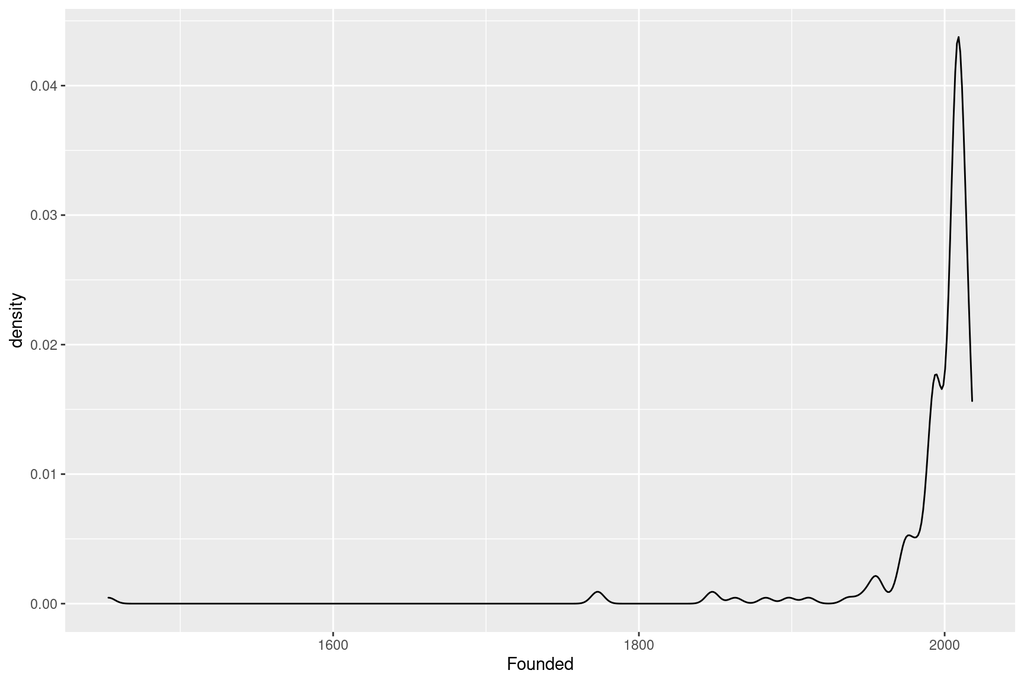

```r
# Density function for establishment dates
ggplot(pdat, aes(x=Founded)) + geom_density()
```

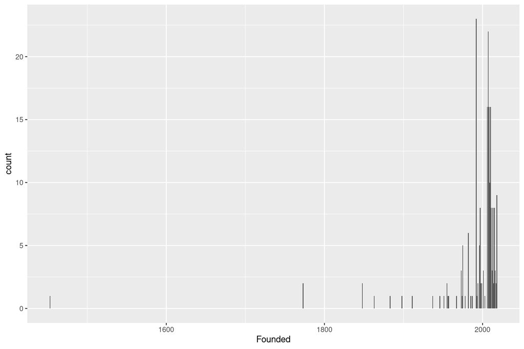

```r
ggplot(pdat, aes(x=Founded)) + geom_bar()
```

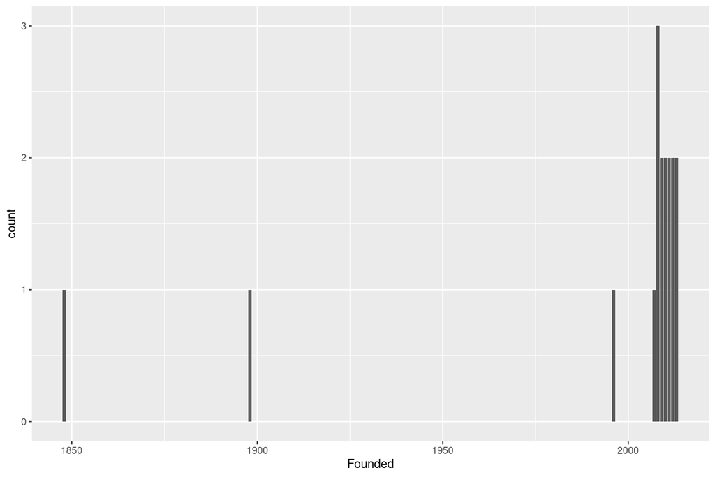

```r
# Density function for establishment dates - for closed ones
ggplot(pdat[!is.na(pdat$Closed),], aes(x=Founded)) + geom_bar()
```

# Get location information from OpenStreetMap

```r
# Get locations
pdat <- setDT(pdat)
# Find universities' location
ploc <- setDT(geocode_OSM(pdat$University, as.data.frame = TRUE))
setnames(ploc, "query", "University")
pdat <- ploc[, .(University, lat, lon)][pdat, on = "University"]

# Find provinces' location and use them for missing values
plocc <- setDT(geocode_OSM(unique(pdat[is.na(lat)]$Province), as.data.frame = TRUE))
pdat[is.na(lat), c("lat", "lon") := .(plocc$lat[match(Province, plocc$query)],
                                      plocc$lon[match(Province, plocc$query)])]

# Get data from the web
# pdat <- read.csv("http://users.metu.edu.tr/etaymaz/econ413/university_data.csv")

# List universities with missing locations
pdat[is.na(pdat$lat),]
```

```
## Empty data.table (0 rows and 7 cols): University,lat,lon,Province,Type,Founded...
```

# Get the map

```r
# Get the world map
tr <- c(left = 25, bottom = 35, right = 45, top = 43)

map1 <- get_map(tr, source = "stamen", maptype = "terrain", zoom = 5)

# Define closed variable
pdat$closed <- !is.na(pdat$Closed)
```

# Location of universities (Stamen map)

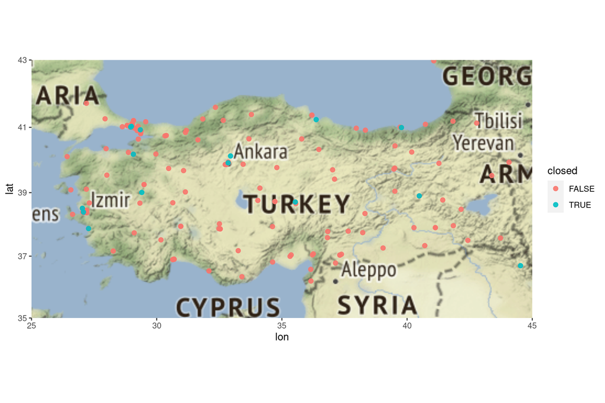

```r
ggmap(map1) + geom_point(data=pdat, aes(x = lon, y = lat, color = closed), size = 2, alpha = 0.9)
```

# Web scrapping - Case 3

```r
# Libraries
library(rvest)
library(ggplot2)
library(stringi)
library(data.table)

# Functions --------------------------------------------------------------------
# Preparering page list
sayfaListesiniHazirla <- function(ii) {
  cat("Page : ", ii, "\n")
  durl <- paste0("https://www.tccb.gov.tr/haberler/?&page=", ii)
  doc <- read_html(durl)
  doc <- html_node(doc, "#divContentList")
  dat <- data.table(tarih = html_text(html_nodes(doc, "dt")),
                    urls = html_attr(html_nodes(doc, "a"), "href"),
                    baslik = html_text(html_nodes(doc, "dd")))
  return(dat)
}

# Scrapping news
haberleriDerle <- function(url) {
  durl <- paste0("https://www.tccb.gov.tr", url)
  doc <- read_html(durl)
  haber <- html_text(html_node(doc, "#divContentArea"))
  return(haber)
}

# Plotting charts
plotKeyWordsChart <- function(x) {
  # tumHaberler[, zaman := yil + floor((ay-1)/6)/2]
  ff <- vector(mode = "list", length = length(x))
  for (i in c(1:length(x))) {
    tumHaberler[, sayi := grepl(x[i], haber)]
    ff[[i]] <- tumHaberler[, .(kelime = stri_trans_totitle(x[i]),
                               sayi = sum(sayi), nhaber = .N), by = yil]
  }
  fff <- do.call("rbind", ff)
  gg  <- ggplot(fff, aes(x = yil, y = 100*sayi/nhaber,
                         color = kelime, group = kelime)) +
    geom_line(size = 1.5) +
    theme_bw(base_size = 24) +
    guides(colour = guide_legend(override.aes = list(size=5))) +
    labs(x = "", y = "Kelime kullanma sıklığı (%)")
  return(gg)
}

# SCRAP THE DATA ---------------------------------------------------------------
# Find the number of pages
# Get news links
tumListe <- lapply(c(1:25), sayfaListesiniHazirla)
```

```
## Page :  1
## Page :  2
## Page :  3
## Page :  4
## Page :  5
## Page :  6
## Page :  7
## Page :  8
## Page :  9
## Page :  10
## Page :  11
## Page :  12
## Page :  13
## Page :  14
## Page :  15
## Page :  16
## Page :  17
## Page :  18
## Page :  19
## Page :  20
## Page :  21
## Page :  22
## Page :  23
## Page :  24
## Page :  25
```

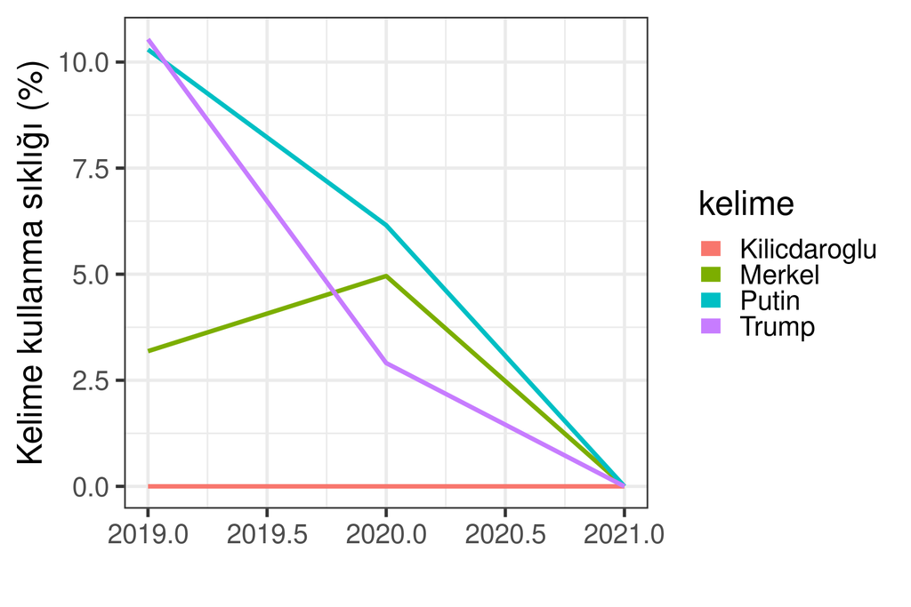

```r
tumHaberler <- do.call("rbind", tumListe)

# Get news - IT MAY TAKE SOME TIME TO RETRIVE THE DATA!!
tumHaberler$haber <- sapply(tumHaberler$urls, haberleriDerle)

# Clean the data  -------------------------------------------------------------
# use only lower case
# There could be some problems with Turkish letters
tumHaberler[, haber := stri_trans_tolower(haber, "tr_TR")]

# Remove \r ve \n
tumHaberler[, haber := gsub("\r", " ", haber, fixed = TRUE)]
tumHaberler[, haber := gsub("\n", " ", haber, fixed = TRUE)]

# Add date variable
tumHaberler[, ay := as.integer(substr(tarih, 4, 5))]
tumHaberler[, yil := as.integer(substr(tarih, 7, 10))]

# Save the data
# save(tumHaberler, file="Data/all_news_5December2020_raw.Rdata")

# Word list --------------------------------------------------------------
wlist <- c("trump", "putin", "merkel", "kilicdaroglu")

# Plot it
plotKeyWordsChart(wlist)
```